💻

# Lecture 9: Effect Modification (Interactions) and Logistic regression

| Dates | @December 9, 2021 |
| --- | --- |
| Type | 📒 Lesson |
| Topic | Introduction to RLinear Model |
| Link |  |

#### 📚 Recommended reading

| Name | Pages |
| --- | --- |
| ggplot2: Elegant Graphics for Data Analysis | 3-31 |

#### 📂 Files

| RMarkdown file | Dataset | Task | Task solution |
| --- | --- | --- | --- |
| https://github.com/fans-stats/intro_to_R_stats/raw/main/lecture_9/lecture_9.Rmd | [https://github.com/fans-stats/intro_to_R_stats/blob/main/datasets/alcohol_intake.sav?raw=true](https://github.com/fans-stats/intro_to_R_stats/blob/main/datasets/job_seek.sav?raw=true) | [https://github.com/fans-stats/intro_to_R_stats/raw/main/lecture_9/lecture_9_tasks.Rmd](https://github.com/fans-stats/intro_to_R_stats/raw/main/lecture_6/lecture_6_tasks.Rmd) | [https://github.com/fans-stats/intro_to_R_stats/raw/main/lecture_9/lecture_9_tasks_solved.Rmd](https://github.com/fans-stats/intro_to_R_stats/raw/main/lecture_6/lecture_6_tasks_solved.Rmd) |

# Summary of session

- Linear model
- ggplot2 concepts

# **Background:**

Job Search Intervention Study is a randomized study that investigates the efficacy of a job training intervention on unemployed workers. The program is designed to not only increase reemployment among the unemployed but also enhance their mental health. The data consists of a sample of n=899 subjects. Several variables have been recorded:

- treat: indicator variable for whether participant was randomly selected for the job training programme (1= treatment group, 0= control group)
- job_seek: a continuous scale measuring the level of job-search self-efficacy with values from 1 to 5.
- depress: post treatment depression score
- sex: gender (0 = male, 1 = female)
- age: age (in years)

# **Background:**

The data file contains crime rate data on 51 US states. Several continuous and categorical variables have been recorded:

- state – US state

- crime – violent crime rate (per 100,000 people)

- murder – murder rate (per 100,000 people)

- metropol – percent living in cities

- white – percent white people

- edu – percent gaining high school education

- poverty – percent below the poverty line

- single – percent lone parents

- urban – a categorised (binary) version of metropol [urban = 1 if metropol >= median (69.8); urban = 0 otherwise)

# **Loading Packages**

```
#install.packages("gmodels")
library(foreign)
library(tidyverse)
library(car) # Remember to install the package 'car' if you do not have it yet!
library(gmodels) # Also install the package 'gmodels' if you do not have it!
```

# **Loading data**

```
url <- 'https://github.com/fans-stats/intro_to_R_stats/blob/main/datasets/crime_rates.sav?raw=true'
dataset <- read.spss(file = url, to.data.frame = TRUE)
dataset <- as_tibble(dataset)
dataset
```

| state<chr> | crime<dbl> | murder<dbl> | metropol<dbl> | white<dbl> | edu<dbl> | poverty<dbl> | single<dbl> | urban<fct> |
| --- | --- | --- | --- | --- | --- | --- | --- | --- |
| AK | 761 | 9 | 41.8 | 75.2 | 86.6 | 9.1 | 14.3 | otherwise |
| AL | 780 | 11.6 | 67.4 | 73.5 | 66.9 | 17.4 | 11.5 | otherwise |
| AR | 593 | 10.2 | 44.7 | 82.9 | 66.3 | 20 | 10.7 | otherwise |
| AZ | 715 | 8.6 | 84.7 | 88.6 | 78.7 | 15.4 | 12.1 | metropol >= median (69.8) |
| CA | 1078 | 13.1 | 96.7 | 79.3 | 76.2 | 18.2 | 12.5 | metropol >= median (69.8) |
| CO | 567 | 5.8 | 81.8 | 92.5 | 84.4 | 9.9 | 12.1 | metropol >= median (69.8) |
| CT | 456 | 6.3 | 95.7 | 89 | 79.2 | 8.5 | 10.1 | metropol >= median (69.8) |
| DE | 686 | 5 | 82.7 | 79.4 | 77.5 | 10.2 | 11.4 | metropol >= median (69.8) |
| FL | 1206 | 8.9 | 93 | 83.5 | 74.4 | 17.8 | 10.6 | metropol >= median (69.8) |
| GA | 723 | 11.4 | 67.7 | 70.8 | 70.9 | 13.5 | 13 | otherwise |

# **Task 2**

Use the appropriate descriptive indices to identify potential typos and if so, clean the dataset. Use the space below to keep a record of the typos you found and then delete them to create a “clean data set”.

```
dataset %>%
  ggplot(aes(x = metropol)) +
    geom_histogram()
```

[figure not shown]

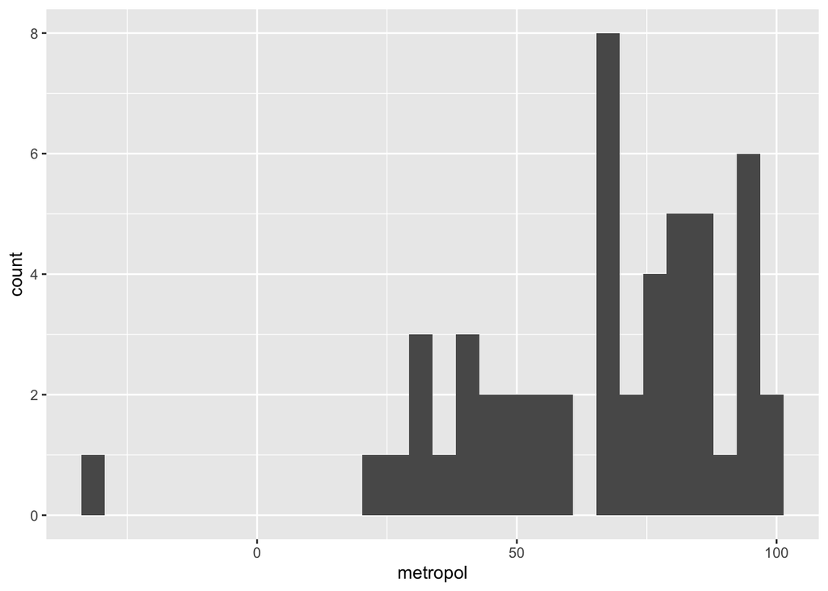

```
dataset$metropol[dataset$metropol == -30.70] <- NA
dataset$murder[dataset$murder == -9] <- NA
```

# **Task 3**

It is hypothesised that urbanicity is a modifier of the effect of poverty on crime. To investigate the effect modification please follow the next steps. a) Use the appropriate R command to create a cross-product (poverty_X_urban) term by multiplying poverty with urban. b) Use a multiple linear regression model to assess if urbanicity is an effect modifier of the poverty-crime association.

```
dataset %>%
  lm(formula = crime ~ urban*poverty) %>%
  summary()
```

```
##
## Call:
## lm(formula = crime ~ urban * poverty, data = .)
##
## Residuals:
##     Min      1Q  Median      3Q     Max
## -723.10 -195.15  -68.22  142.03 1136.90
##
## Coefficients:
##                                        Estimate Std. Error t value Pr(>|t|)
## (Intercept)                              112.76     219.33   0.514  0.60959
## urbanmetropol >= median (69.8)          -416.52     284.78  -1.463  0.15023
## poverty                                   21.80      14.25   1.530  0.13276
## urbanmetropol >= median (69.8):poverty    57.33      18.95   3.025  0.00402 **
## ---
## Signif. codes:  0 '***' 0.001 '**' 0.01 '*' 0.05 '.' 0.1 ' ' 1
##
## Residual standard error: 302.4 on 47 degrees of freedom
## Multiple R-squared:  0.5581, Adjusted R-squared:  0.5299
## F-statistic: 19.78 on 3 and 47 DF,  p-value: 1.954e-08
```

1. What does the regression coefficient of poverty_X_urban tell you? Comment on the statistical significance of the coefficient.

The regression coefficient of poverty_X_urban represents the interaction effect between poverty and urbanicity. The p-value (p=0.004) suggests that interaction effect is statistically significant. This implies that both predictors jointly affect crime rate, but their effects are not independent of each other. Effect of poverty depends on urbanicity and vice-versa.

The estimated coefficient (57.326) can be interpreted as the difference of the effect of poverty on crime rate between highly urbanised (urban=1) and low-urbanised (urban=0) states.

1. Do the coefficients of poverty and urban carry their usual meaning? Interpret their estimated values from the fitted interaction model.

The coefficients of the predictors poverty and urban do not carry their usual interpretations because of the presence of an interaction (cross-product) term involving these predictors. For the interaction model, the coefficient of poverty can be interpreted as the effect of poverty on crime rate when urban=0. The estimated coefficient (21.798) implies that, in low-urbanised states, one unit increase in poverty leads to 21.798 units increase in crime rate. Similarly, the coefficient of urban (-416.523) represents the effect of urbanicity on crime rate when poverty=0. This coefficient may not be of great interest in this study as the zero poverty is an unrealistic value. Interaction term is the difference between low urbanised and high urbanised areas in the the poverty –crime association

1. What is the estimated linear effect of poverty on crime rate for low-urbanised (urban=0) and highly urbanised (urban =1) states?

The general formula for the effect of poverty on crime rate based on the above interaction model is given by: Effect of poverty = Coefficient of poverty + Coefficient of interaction term * Urbanicity Therefore: Effect of poverty for low urbanised states = 21.798 + 57.326 x 0 = 21.798 Effect of poverty for highly urbanised states = 21.798 + 57.326 x 1 = 79.124

# **Task 4**

1. For the poverty by urban interaction model in Task 3, calculate the standardised DFBETA and DFFIT measures.

```
dataset %>%
  dplyr::mutate(dfbetas = dfbetas(
    lm(formula = crime ~ urban*poverty)
    )[,4]) %>%
  dplyr::mutate(dffits = dffits(lm(formula = crime ~ urban*poverty)))
```

| state<chr> | crime<dbl> | murder<dbl> | metropol<dbl> | white<dbl> | edu<dbl> | poverty<dbl> | single<dbl> | urban<fct> | dfbetas<dbl> | Property |
| --- | --- | --- | --- | --- | --- | --- | --- | --- | --- | --- |
| AK | 761 | 9 | 41.8 | 75.2 | 86.6 | 9.1 | 14.3 | otherwise | 0.3435916832 |  |
| AL | 780 | 11.6 | 67.4 | 73.5 | 66.9 | 17.4 | 11.5 | otherwise | -0.0928954411 |  |
| AR | 593 | 10.2 | 44.7 | 82.9 | 66.3 | 20 | 10.7 | otherwise | -0.0296789861 |  |
| AZ | 715 | 8.6 | 84.7 | 88.6 | 78.7 | 15.4 | 12.1 | metropol >= median (69.8) | -0.0309762342 |  |
| CA | 1078 | 13.1 | 96.7 | 79.3 | 76.2 | 18.2 | 12.5 | metropol >= median (69.8) | -0.0249617289 |  |
| CO | 567 | 5.8 | 81.8 | 92.5 | 84.4 | 9.9 | 12.1 | metropol >= median (69.8) | -0.0319941635 |  |
| CT | 456 | 6.3 | 95.7 | 89 | 79.2 | 8.5 | 10.1 | metropol >= median (69.8) | -0.0445723334 |  |
| DE | 686 | 5 | 82.7 | 79.4 | 77.5 | 10.2 | 11.4 | metropol >= median (69.8) | -0.0615794436 |  |
| FL | 1206 | 8.9 | 93 | 83.5 | 74.4 | 17.8 | 10.6 | metropol >= median (69.8) | 0.039302103 |  |
| GA | 723 | 11.4 | 67.7 | 70.8 | 70.9 | 13.5 | 13 | otherwise | 0.0502300318 |  |

# **Background:**

The data set consists of a sample of n=1000 sixteen years old children. Several continuous and categorical variables have been recorded:

- weight – weight in kg at age 16

- sex – gender of child (0 = male, 1 = female)

- height – height in cm at age 16

- class – registrar general’s classification of social class (7 categories)

- malcat – Malaise score (0=no, 1=yes)

- reading – Reading score

- scd – CD rating

- sha – Hyperactivity (HA) rating

# **Loading data**

```
url <- 'https://github.com/fans-stats/intro_to_R_stats/blob/main/datasets/child_dev_a.sav?raw=true'
dataset <- read.spss(file = url, to.data.frame = TRUE)
dataset <- as_tibble(dataset)
dataset
```

| id<dbl> | sex<fct> | reading<dbl> | class<dbl> | height<dbl> | weight<dbl> | scd<dbl> | sha<dbl> | pdep<dbl> | mal<dbl> | Property |
| --- | --- | --- | --- | --- | --- | --- | --- | --- | --- | --- |
| 1 | Male | 27 | 7 | 173 | 72.33 | 2 | 1 | 3 | 3 | Untitled |
| 2 | Male | 23 | 2 | 157 | 41.28 | 1 | 1 | 3 | 2 | Untitled |
| 3 | Male | 30 | 2 | 174 | 58.29 | 5 | 3 | 1 | 0 | Untitled |
| 4 | Male | 15 | 4 | 170 | 69.17 | 1 | 1 | 1 | 6 | Untitled |
| 5 | Male | 26 | 2 | 161 | 51.03 | 3 | 2 | 2 | 1 | Untitled |
| 6 | Male | 28 | 1 | 182 | 71.67 | 1 | 1 | 2 | 3 | Untitled |
| 7 | Male | 13 | 4 | 170 | 62.14 | 5 | 1 | 4 | 0 | Untitled |
| 8 | Male | 23 | 6 | 171 | 60.33 | 4 | 1 | 3 | 4 | Untitled |
| 9 | Male | 30 | 2 | 171 | 49.44 | 1 | 1 | 1 | 3 | Untitled |
| 10 | Male | 30 | 2 | 173 | 67.13 | 4 | 1 | 2 | 1 | Untitled |

# **Task 1:**

We want to compare the effects of a child’s gender on the risk of depression at the age of 22 measured as the dichotomised malaise score where 0 = No malaise and 1 = Yes malaise. Calculate your answer to 3 decimal places

```
# First we look at the crosstables using the CrossTable() function from package 'gmodels'.

CrossTable(dataset$malcat, dataset$sex,
           format=c("SPSS"),
           prop.r = FALSE,
           prop.t = FALSE,
           prop.chisq=FALSE)
```

```
##
##    Cell Contents
## |-------------------------|
## |                   Count |
## |          Column Percent |
## |-------------------------|
##
## Total Observations in Table:  1000
##
##                | dataset$sex
## dataset$malcat |     Male  |   Female  | Row Total |
## ---------------|-----------|-----------|-----------|
##             No |      465  |      437  |      902  |
##                |   94.705% |   85.855% |           |
## ---------------|-----------|-----------|-----------|
##            Yes |       26  |       72  |       98  |
##                |    5.295% |   14.145% |           |
## ---------------|-----------|-----------|-----------|
##   Column Total |      491  |      509  |     1000  |
##                |   49.100% |   50.900% |           |
## ---------------|-----------|-----------|-----------|
##
##
```

Risk of having malaise in males = 26 ÷ 491 = 0·053 Risk of having malaise in females = 72 ÷ 509 = 0·141 We can compare the risk for each of the groups using the risk ratio. (Risk when male) ÷ (Risk when female) = 0·053 ÷ 0·14 = 0.376 Those who were male had 0.37 times the risk of having malaise at 22 compared to those who were female.

We can also present risk as a percentage using the following formula % decrease = (1 - RR) x 100 Males had a 63% reduction in risk of malaise at 22 compared to females.

You could have also calculated this as (Risk when female) ÷ (Risk when male) = 0.14 ÷ 0.053 = 2.642 Those who were female had 2.64 times the risk of having malaise at 22 compared to those who were male.

We can also present risk as a percentage using the following formula % increase = (RR - 1) x 100 Those who were female had a 164% increase in risk of having malaise at 22 compared to males.

# **Task 2:**

We want to compare the effects of a child’s gender on the odds of depression measured as the dichotomous malaise score where 0 = No malaise and 1 = Yes malaise. Calculate your answer to 3 decimal places (3dp)

Odds of having malaise in males = 26 ÷ 465 = 0·056 Odds of having malaise in females = 72 ÷ 437 = 0·165 We can compare the odds for each of the groups using the odds ratio. (Odds when male) ÷ (Odds when female) = 0·056 ÷ 0·165 = 0.339 So the odds of having malaise at 22 when the child is male is about a 1/3 of the odds of females having malaise at 22. You could have also calculated this as (Odds when female) ÷ (Odds when male) = 0.165 ÷ 0.056 = 2.946 So the odds of having malaise at 22 when the child is female is about 3 times of the odds of a male child.

# **Task 3:**

Is there an association between a child’s gender and them suffering malaise at age 22?

```
#install.packages('fmsb')library(fmsb)

dataset %>%
  glm(formula = malcat ~ sex, family = binomial(link='logit')) %>%
  summary()
```

```
##
## Call:
## glm(formula = malcat ~ sex, family = binomial(link = "logit"),
##     data = .)
##
## Deviance Residuals:
##     Min       1Q   Median       3Q      Max
## -0.5523  -0.5523  -0.3299  -0.3299   2.4242
##
## Coefficients:
##             Estimate Std. Error z value Pr(>|z|)
## (Intercept)  -2.8839     0.2015 -14.311  < 2e-16 ***
## sexFemale     1.0807     0.2383   4.535 5.76e-06 ***
## ---
## Signif. codes:  0 '***' 0.001 '**' 0.01 '*' 0.05 '.' 0.1 ' ' 1
##
## (Dispersion parameter for binomial family taken to be 1)
##
##     Null deviance: 641.33  on 999  degrees of freedom
## Residual deviance: 618.32  on 998  degrees of freedom
## AIC: 622.32
##
## Number of Fisher Scoring iterations: 5
```

```
dataset %>%
  glm(formula = malcat ~ sex,family = binomial(link='logit')) %>%
  fmsb::NagelkerkeR2()
```

```
## $N
## [1] 1000
##
## $R2
## [1] 0.0480488
```

H0: there is no association between gender and malaise at age 22 H1: there is an association between gender and malaise at age 22

There was a significant improvement to the constant only model. Nagelkerke 𝑅2R2 = 4.8% of the variation in malaise can be explained by the model including gender.

# **Task 4**

```
dataset %>%
  dplyr::mutate(class = as.factor(class)) %>%
  glm(formula = malcat ~ sex + reading + scd + sha + class,
      family = binomial(link='logit')) %>%
  summary()
```

```
##
## Call:
## glm(formula = malcat ~ sex + reading + scd + sha + class, family = binomial(link = "logit"),
##     data = .)
##
## Deviance Residuals:
##     Min       1Q   Median       3Q      Max
## -1.1901  -0.4963  -0.3783  -0.2597   2.7058
##
## Coefficients:
##             Estimate Std. Error z value Pr(>|z|)
## (Intercept) -3.63017    0.90987  -3.990 6.61e-05 ***
## sexFemale    1.27816    0.25220   5.068 4.02e-07 ***
## reading     -0.03455    0.01651  -2.092   0.0364 *
## scd          0.11012    0.08626   1.277   0.2018
## sha          0.19703    0.10811   1.822   0.0684 .
## class2       0.72485    0.77282   0.938   0.3483
## class3       0.36732    0.84347   0.435   0.6632
## class4       0.78171    0.74991   1.042   0.2972
## class5       0.78876    0.77905   1.012   0.3113
## class6       1.34293    0.85463   1.571   0.1161
## class7       1.56138    0.85708   1.822   0.0685 .
## ---
## Signif. codes:  0 '***' 0.001 '**' 0.01 '*' 0.05 '.' 0.1 ' ' 1
##
## (Dispersion parameter for binomial family taken to be 1)
##
##     Null deviance: 641.33  on 999  degrees of freedom
## Residual deviance: 590.28  on 989  degrees of freedom
## AIC: 612.28
##
## Number of Fisher Scoring iterations: 6
```

```
dataset %>%
  dplyr::mutate(class = as.factor(class)) %>%
  glm(formula = malcat ~ sex + reading + scd + sha + class,
      family = binomial(link='logit')) %>%
  NagelkerkeR2()
```

```
## $N
## [1] 1000
##
## $R2
## [1] 0.1051232
```

There was a significant improvement to the constant only model. Nagelkerke R^2 = 10.5% of the variation in malaise can be explained by the model including gender, reading score, scd, sha and class.